# From forest to mountain: grouse in the hunting bag

Four species, six Norwegian municipalities, and the limits of harvest data

Author

Yiyao

## Question and motivation

**Do harvest patterns differ between forest-associated grouse and ptarmigan across contrasting Norwegian landscapes?** This exploratory study compares four species in six municipalities during hunting years 2008–2009 through 2018–2019, using a location map and official land cover statistics to give the harvest records ecological context.

The species provide a useful contrast, but they are not interchangeable habitat indicators. Capercaillie is associated with older forest, whereas black grouse often uses earlier successional habitats (Gregersen and Gregersen 2009). Willow ptarmigan uses shrub rich subalpine and tundra habitats; Norwegian field studies found selection near the treeline and for relatively rich vegetation (Kvasnes et al. 2018). Rock ptarmigan (Lagopus muta) is primarily associated with rocky habitats in high-alpine and high-Arctic tundra (Henden et al. 2017).

Thus, the motivating expectation is a change in the mix of harvested species across forest and open upland settings, rather than a uniform north–south trend.

**NoteScope**

4 species · 6 municipalities · 11 hunting years · 205 observed values · 59 missing values. This is a comparison of published harvests, not a survey of bird abundance or a test of what causes population change.

## Where, and why these places?

The six cases span southern forest landscapes, central mountains and northern coastal/inland settings. They were chosen for a compact geographical contrast after initial data inspection, not by random sampling or a pre-registered selection rule. They cannot represent Norway as a whole.

| Municipality | Role in the comparison |
| --- | --- |
| Kongsberg | Southern case with extensive conifer forest |
| Trysil | Southeastern forest–upland mosaic; contrasts with Kongsberg |
| Oppdal | Central mountain case with relatively little forest |
| Rana | Northern coastal-to-mountain case |
| Alta | Far-northern fjord–upland case |
| Kautokeino | Far-northern inland plateau; contrasts with Alta |

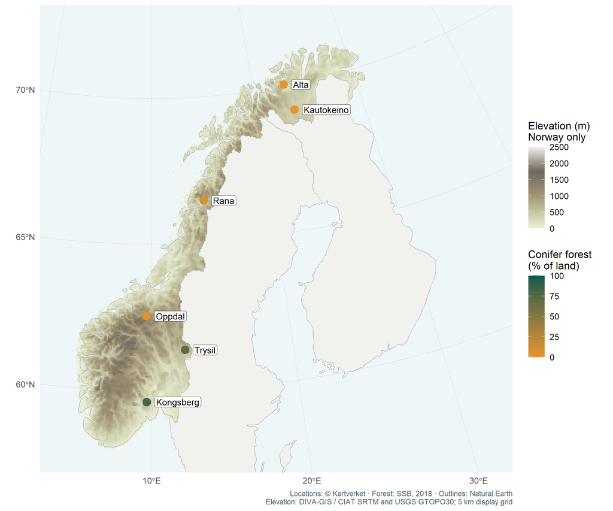

Figure 1: The six study municipalities over a Norway elevation background. Points are official points within municipalities, not bird observations or hunting locations. Point colour shows conifer forest as a percentage of terrestrial area in 2018. The background shows elevation, coarsened to a 5 km display grid; neighbouring countries have no elevation layer. Municipal boundaries are not shown. Projection: ETRS89 / LAEA Europe. Sources: © Kartverket (CC BY 4.0), SSB table 09594 (CC BY 4.0), Natural Earth v5.1.2 (public domain), and DIVA-GIS elevation (CIAT SRTM: Jarvis et al., 2008; USGS GTOPO30).

land cover measurements support the intended contrast: conifer forest covers 80.1% of Kongsberg and 71.3% of Trysil, compared with 4.3% of Oppdal. Forest type also matters: Kautokeino has 39.4% total forest but only 0% conifer forest. Total forest cover alone is therefore a coarse description of habitat for these birds.

## Data and analysis

**Harvests.** The local source is an extract of the course file `smallGame.RDS`. All 264 selected cells, including their missing status, were checked against [SSB table 07514](https://www.ssb.no/en/statbank1/table/07514) on 23 October 2026. The original label “Ptarmigan” is displayed here as “Rock ptarmigan”. A hunting year runs from 1 April to 31 March; 2018 on the figure means 2018–2019. We retain the original period to avoid extending across the extensive 2020 municipality changes. Oppdal’s 2018 code change is explicitly documented in `data/README.md` and was handled during source verification.

**Environment and location.** [SSB table 09594](https://www.ssb.no/en/statbank1/table/09594) provides 2018 land cover areas. Forest percentages use terrestrial area, excluding inland and marine water; nested forest subclasses are not counted twice. This single snapshot gives landscape context, not a reconstruction of habitat during every hunting year. SSB warns that changes in mapping coverage prevent simple comparisons of this table across years. Map positions come from [Kartverket’s municipality API](https://ws.geonorge.no/kommuneinfo/v1/), with a [Natural Earth](https://www.naturalearthdata.com/) reference map. The Norway elevation raster is distributed by [DIVA-GIS / UC Davis](https://geodata.ucdavis.edu/diva/msk_alt/). The 30-arc-second product combines SRTM with GTOPO30 at northern latitudes; see the [elevation documentation](https://rspatial.github.io/geodata/reference/elevation.html). We aggregate and project it to a 5 km grid for the national overview. It is a terrain background, not a municipal mean elevation or a measurement of hunted habitat. **Conifer forest percentage** is the municipal environmental parameter used for the quantitative comparison below. Inputs are cached in the project. A fresh clone downloads the elevation file once from its provider; subsequent runs require no data downloads.

**Cleaning and summaries.** `clean_data()` reshapes the 44 source rows into 264 municipality–species–year observations, standardises labels, and validates identifiers, non-negative harvests and unique records. Missing values are retained, not replaced with zero. The table reports each mean together with the number of available years. An entirely missing series has no mean. Because missingness may reflect suppression or non-availability, means over different sets of years may not be directly comparable.

We plot annual records and describe the patterns. No significance tests, population trend model or causal regression is fitted to these six selected municipalities. Municipal area, hunting effort and habitat availability differ; raw totals are neither densities nor effort-standardised harvest rates.

## What the data show

Table 1: land cover context and mean annual harvest (birds), 2008–2009 to 2018–2019. Parentheses give observed years out of 11; NA means no observations. Forest percentages refer to terrestrial area in 2018. Willow and Rock denote the two ptarmigan species. Means with different coverage require caution.

| Municipality | Forest (%) | Conifer (%) | Capercaillie | Black grouse | Willow | Rock |
| --- | --- | --- | --- | --- | --- | --- |
| Kongsberg | 81.9 | 80.1 | 112 (11/11) | 340 (11/11) | NA (0/11) | 0 (3/11) |
| Trysil | 76.6 | 71.3 | 828 (11/11) | 993 (11/11) | 1314 (11/11) | 188 (8/11) |
| Oppdal | 16.5 | 4.3 | 20 (1/11) | 32 (4/11) | 1727 (11/11) | 750 (11/11) |
| Rana | 24.0 | 8.2 | 52 (9/11) | 62 (9/11) | 2227 (11/11) | 1614 (11/11) |
| Alta | 21.9 | 2.2 | 0 (8/11) | 0 (7/11) | 1741 (11/11) | 1600 (11/11) |
| Kautokeino | 39.4 | 0.0 | 0 (8/11) | 12 (6/11) | 4836 (11/11) | 240 (10/11) |

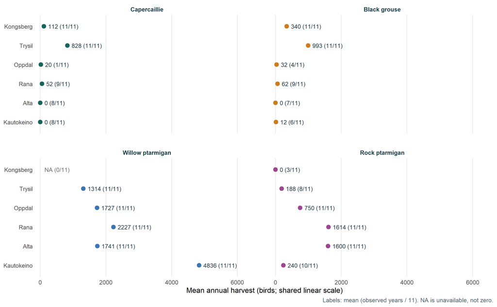

Figure 2: Mean annual harvest by species and municipality. All four panels use the same linear horizontal scale, so distances are directly comparable. Labels give the mean and observed years out of 11. Missing series are labelled NA with no point; reported zeros have a point at zero. Unequal coverage limits comparisons of means. Source: SSB table 07514 (CC BY 4.0).

**The mix of harvests differs among landscapes.** In Trysil, all 11 years are available for capercaillie, black grouse and willow ptarmigan, with means of 828, 993 and 1314 birds per year, respectively. This mixed harvest is consistent with a municipality containing both forest and upland environments. In Kautokeino, willow ptarmigan averages 4836 birds across 11 observed years. Rana and Alta also have substantial rock ptarmigan harvests: means of 1614 and 1600 birds, both with complete coverage.

**Missing does not mean absent.** Kongsberg has no available willow ptarmigan values in this extract. That prevents a quantitative comparison of its willow ptarmigan harvest; it does not demonstrate that the species is absent. The table’s observed year counts are part of the result, not just a technical detail. The same caution applies to incomplete forest-grouse series farther north.

### Does conifer forest cover help explain the spatial contrast?

Conifer forest percentage is a biologically motivated habitat descriptor for the two forest associated species. It describes the municipality as a whole, whereas the elevation at a map point would describe only that one location. It is still a coarse proxy: black grouse also uses open and early successional habitats, and neither species responds to forest percentage alone.

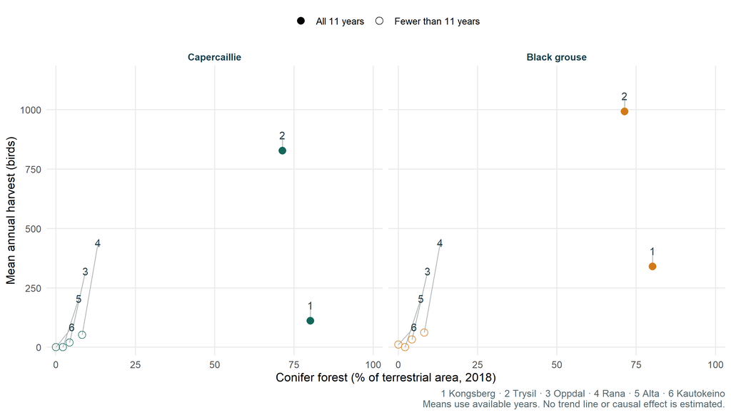

Figure 3: Conifer forest percentage versus mean annual forest-grouse harvest. Both panels share the same axes. Numbers identify municipalities using the key below the figure. Filled points have all 11 hunting years; open points have incomplete coverage (see Table 1). Leader lines connect displaced number labels to their observations. This is a descriptive comparison of six selected municipalities, not an estimated causal effect. Sources: SSB tables 07514 and 09594 (CC BY 4.0).

The two conifer rich cases, Kongsberg and Trysil, have larger mean harvests of both forest species than the four other cases. However, **more conifer cover does not consistently mean more harvest**: Kongsberg has a higher conifer percentage than Trysil, yet lower harvests of both species. This contrast supports investigating habitat while showing why cover alone is insufficient. Municipal area, forest structure, hunting effort and incomplete observations remain alternative explanations. The environmental parameter was chosen for its ecological relevance, not by screening predictors for a significant result.

### Annual variation on a common scale

The annual panels below share one vertical scale. A peak of the same height therefore represents the same number of birds in every municipality. Smaller series are visually compressed by the large Kautokeino peak; the mean harvest dot plot above provides labelled values for the broader spatial comparison.

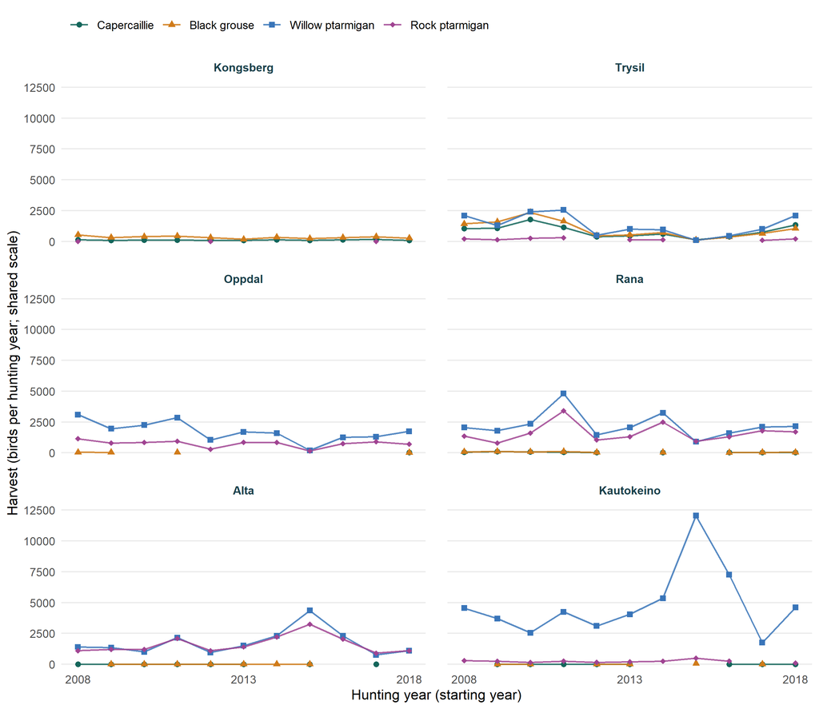

Figure 4: Annual harvest estimates for four grouse species. All six panels use the same linear vertical scale, allowing comparison of absolute totals. Missing values produce gaps and entirely missing series are not drawn. Explicit reported zeros remain zero. The horizontal axis gives the hunting year’s starting year. Source: SSB table 07514 (CC BY 4.0).

## Interpretation in light of the literature

The spatial contrast is **consistent with habitat differences**, but this analysis does not establish that forest cover or terrain caused the harvest patterns. The studies below help frame plausible mechanisms and identify the measurements that are missing from this coursework dataset.

**Habitat composition and forest structure.** Gregersen and Gregersen (Gregersen and Gregersen 2009) examined longer Norwegian harvest records and discussed species specific habitat requirements, forestry and climate. Their work supports distinguishing capercaillie from black grouse rather than treating all forest birds as one ecological response. Our forest percentages contain no information on stand age, management, understory or the places actually hunted.

**Vegetation and terrain.** Kvasnes and colleagues (Kvasnes et al. 2018) used Norwegian field observations and environmental predictors to identify willow ptarmigan habitat selection near the treeline, in richer vegetation and on intermediate slopes. This gives a biological basis for contrasting forest and mountain settings. Our municipal land cover summaries are much coarser: a map point is not a measured habitat, and the elevation background has not been summarised over municipal boundaries or hunting locations. We have not analysed slope or treeline distance. The map therefore motivates a hypothesis rather than testing a topographic mechanism.

**Annual fluctuations and food webs.** Hjeljord and Loe (Hjeljord and Loe 2022) analysed a 142-year series of willow ptarmigan catch per unit effort. Rodent peaks and spring/early-summer atmospheric conditions helped explain variation; the authors could not directly attribute the long-term decline to climate change. Predator–prey dynamics and weather are therefore plausible explanations worth investigating, but the shorter harvest series here contain no rodent, predator or weather measurements. We cannot assign an individual peak or trough to them.

**Hunters are part of the measurement process.** Andersen and Kaltenborn (Andersen and Kaltenborn 2013) found no simple linear relationship between seasonal catch per unit effort and independently estimated willow ptarmigan density in their study. Hunting technique, effort, experience and accessibility mattered. Our unstandardised totals provide even less control for these influences. Reporting, harvest restrictions and SSB estimation also affect the records; see [SSB’s methods](https://www.ssb.no/en/jord-skog-jakt-og-fiskeri/jakt/statistikk/smavilt-og-radyrjakt).

The defensible conclusion is that these selected municipalities show different harvest compositions alongside a clear contrast in forest type and coverage. The pattern is ecologically interpretable, while incomplete records and unmeasured hunting activity limit stronger conclusions. A next study should combine standardised bird surveys, hunting days, regulations and habitat measurements at matched spatial scales before estimating causal effects.

## Reproducibility and editing

The `targets` pipeline tracks source CSVs, the map file, cleaning, summaries, four figures and this Quarto report. `renv.lock` records package versions; Quarto is installed separately. See `README.md` for the Windows/VS Code setup. The project is available on GitHub: YiyaoChen16/bio940-grouse-harvest.

Edit the ordinary paragraphs in `report.qmd`, save the file, then run `Rscript -e 'targets::tar_make()'` in the VS Code PowerShell terminal at the project root. Reopen or refresh `report.html`. Generated numbers come from R code; do not replace them by hand. See `EDITING.md` for a short walkthrough.

**Software used to render this report**

```
R version 4.6.1 (2026-06-24 ucrt)
```

```
Quarto 1.10.19
```

| Package | Version |
| --- | --- |
| targets | 1.12.0 |
| tarchetypes | 0.14.1 |
| renv | 1.3.1 |
| dplyr | 1.2.1 |
| tidyr | 1.3.2 |
| ggplot2 | 4.0.3 |
| sf | 1.1.3 |
| terra | 1.9.50 |
| quarto | 1.5.1 |
| knitr | 1.52 |
| rmarkdown | 2.32 |

## References

Andersen, Oddgeir, and Bjørn Petter Kaltenborn. 2013. “Does a Hunter’s Catch-Per-Unit-Effort Reflect Willow Ptarmigan Abundance?” *Utmark*, no. 2b. https://utmark.org/portals/utmark/utmark_old/utgivelser/pub/2013-2b/fagfelle/Andersen_Kaltenborn_Utmark_2013-2b.html.

Gregersen, Finn, and Håkon Gregersen. 2009. “Ongoing Population Decline and Range Contraction in Norwegian Forest Grouse.” *Ornis Norvegica* 32: 179–89. https://doi.org/10.15845/on.v32i0.163.

Henden, John-André, Rolf Anker Ims, Eva Fuglei, and Åshild Ønvik Pedersen. 2017. “Changed Arctic-Alpine Food Web Interactions Under Rapid Climate Warming: Implication for Ptarmigan Research.” *Wildlife Biology* 2017: 1–11.

Hjeljord, Olav, and Leif Egil Loe. 2022. “The Roles of Climate and Alternative Prey in Explaining 142 Years of Declining Willow Ptarmigan Hunting Yield.” *Wildlife Biology* 2022 (6): e01058. https://doi.org/10.1002/wlb3.01058.

Kvasnes, Mikkel Andreas Jørnsøn, Hans Christian Pedersen, and Erlend Birkeland Nilsen. 2018. “Quantifying Suitable Late Summer Brood Habitats for Willow Ptarmigan in Norway.” *BMC Ecology* 18: 41. https://doi.org/10.1186/s12898-018-0196-6.